# Distance, Mobility, and Mode Choice: A Spatial Analysis of School Travel Behaviour in Ireland

### Judith Beltrán López, Sananthaa Jagadesan Senthamaraikannan<sup>1</sup>

##### <sup>1</sup> School of Mathematical and Statistical Sciences, University of Galway

# Background

- Daily travel to school significantly influences physical activity levels in children and adolescents
- Increased use of unhealthy transport has reduced walking and cycling
- Active travel provides important opportunities for regular physical activity
- In Ireland, school location, distance to school, and neighbourhood features affect travel choices
- Travel habits formed in childhood often continue into adulthood

# Objectives

1. Map and analyse the spatial distribution of schools across Ireland.
2. Examine the distance between students’ residential locations and their schools, and investigate student mobility related to school attendance.
3. Analyse school travel behaviour and assess the prevalence of healthy versus less healthy commuting modes.
4. Explore the relationship between school proximity, travel mode, and potential health implications.

# Datasets

Data on schools in Ireland are of the following Types:

- School-Level Data (Department of Education): School type, enrolment, and geographic location (Eircode,latitude, longitude).
- Settlement-Level Travel Data (CSO): Census data on modes of travel to education at settlement level across multiple years.
- Spatial Boundary Data (CSO): Geographic boundaries for towns and urban areas used for spatial mapping and analysis.

# Early Results

[interactive chart not shown]

Figure 1: Spatial distribution of schools across Ireland

Kriging is a geostatistical interpolation technique that uses spatial relationships to estimate values at unsampled locations, helping to reveal spatial patterns and inequalities in school locations, travel behaviour, and related health impacts.

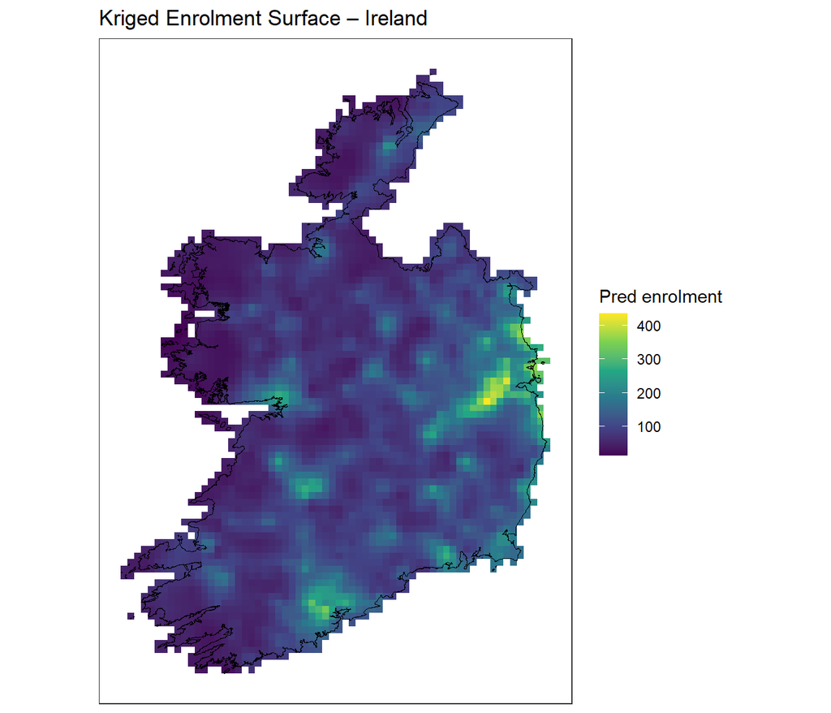

Figure 2: Kriging schools Ireland

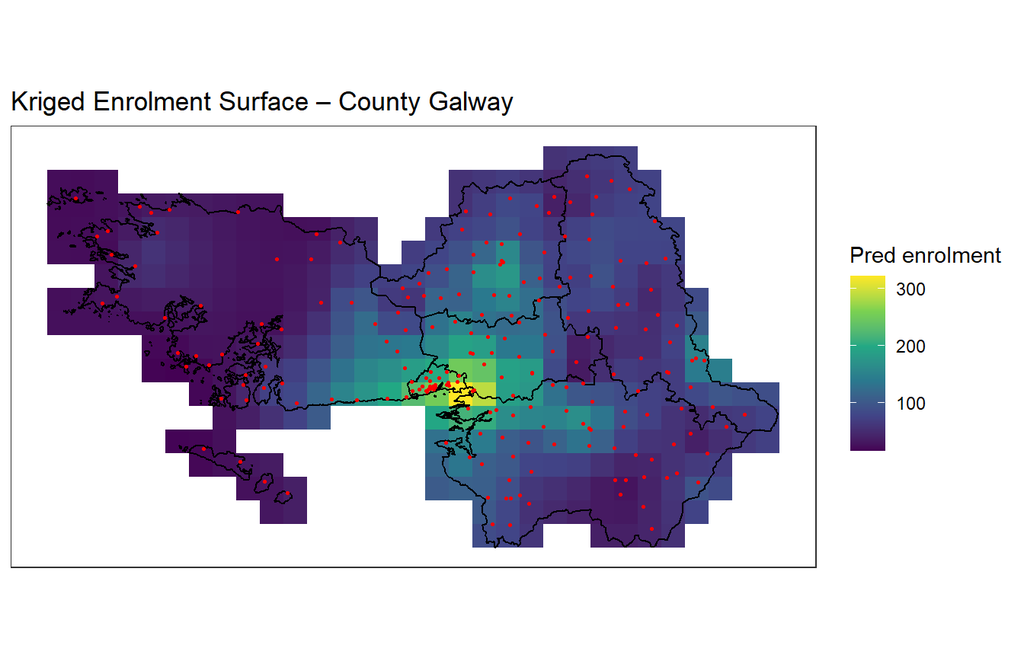

Figure 3: Kriging schools in Co Galway

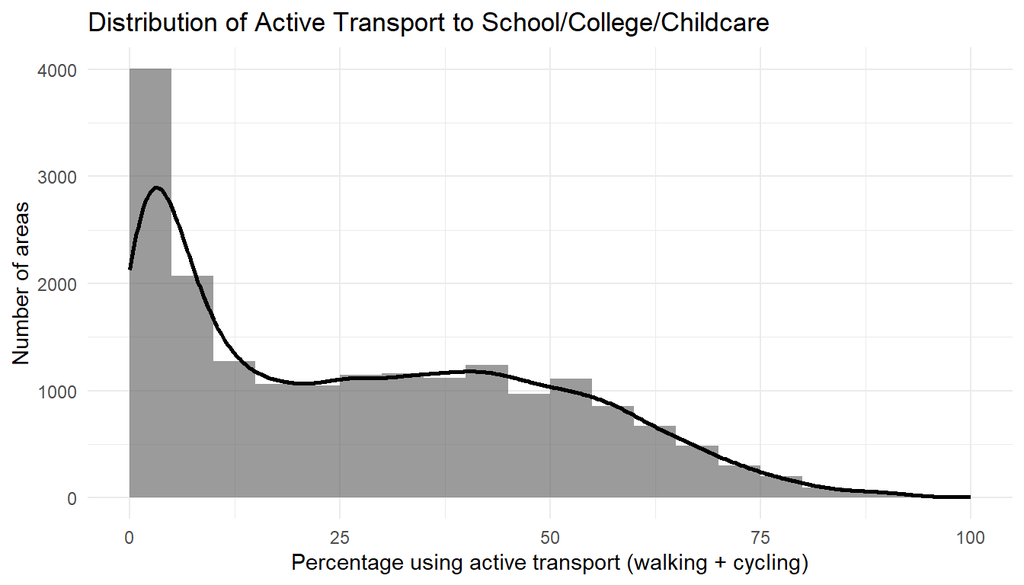

Figure 4: Histogram of active transport in Ireland

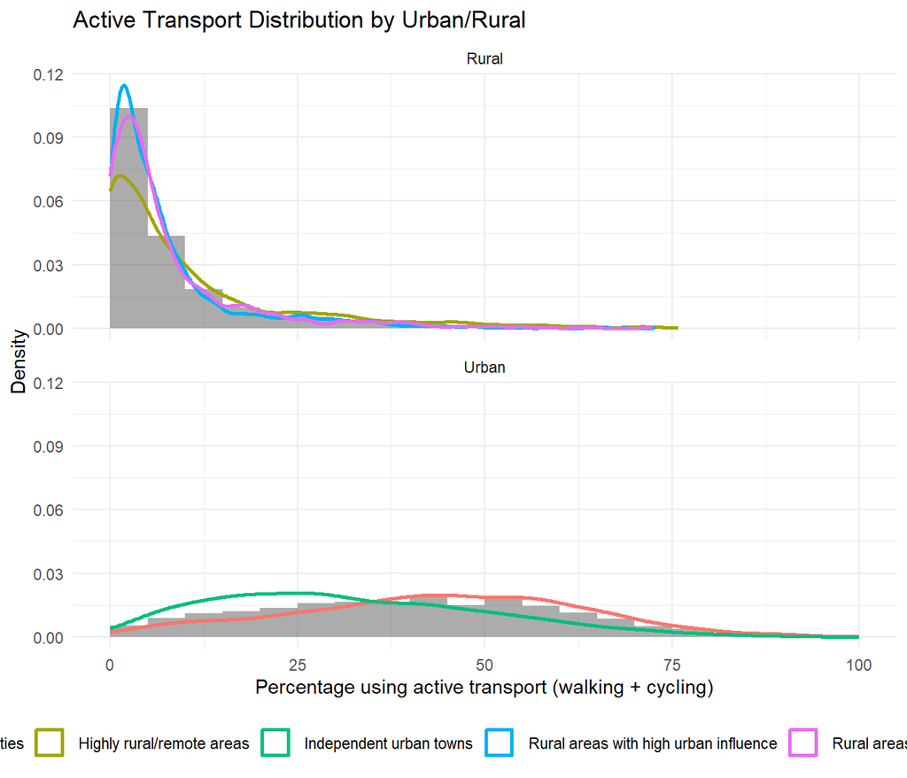

Figure 5: Histogram of active transport in Ireland splitted in Rural and Urban places

# Next Project Steps

- Define predictor variables (e.g. enrolment size, accessibility, resource availability)
- Control for confounding factors (socioeconomic context, location, school size, demographics)
- Apply county-level kriging to examine spatial variation in school enrolment
- Extend analysis using regression or multivariable models to assess relationships between distance, travel mode, and school characteristics

# GitHub

This project can be viewed at our GitHub repository here: https://github.com/judithbeltranlopez/Final-Project

# Bibliography

Data:

- Department of Education (Ireland). *Data on Individual Schools*.  
  https://www.gov.ie/en/department-of-education/collections/data-on-individual-schools/
- Central Statistics Office (CSO). *SAP2022T11T1TOWN22*.  
  https://data.cso.ie/table/SAP2022T11T1TOWN22
- Central Statistics Office (CSO). *SAP2016T11T1SET*.  
  https://data.cso.ie/table/SAP2016T11T1SET
- Central Statistics Office (CSO). *E6013*.  
  https://data.cso.ie/table/E6013
- Central Statistics Office (CSO). *Census 2022 Small Area Population Statistics*.  
  https://www.cso.ie/en/census/census2022/census2022smallareapopulationstatistics/

Research Context:

- Why are teens half as likely to walk or cycle to school in Dublin as Dunshaughlin? https://www.rte.ie/brainstorm/2024/0209/1415046-teens-schools-ireland-active-transport-cycling-walking-educational-provision/
- Children from these communities’: unequal school provision, segregation, and the Irish educational landscape https://www.tandfonline.com/doi/full/10.1080/03323315.2022.2118152